[figure not shown]

In this series we are trying to reproduce the models and examples listed in the book “Analysis of Financial Time Series, 3rd Edition”, by Ruey S. Tsay, using Stan https://mc-stan.org/ and the package RStan https://cran.r-project.org/web/packages/rstan/index.html. The main repository for the presented models and data can be found at https://github.com/marcomarconi/AFTS_with_Stan.

```r
{
  require(tidyverse)
  require(rstan)
  rstan_options(auto_write = TRUE)
  rstan_options(javascript = FALSE)
  theme_set(theme_classic(base_size = 24))
}
```

## 8.2 VECTOR AUTOREGRESSIVE MODELS

Vector autoregressive models are the multivariate version of AR processes, a VAR(1) is defined as follows:

$$r_t = \phi_0 + \Phi r_{t-1} + a_{t}$$
where $\phi_0$ is a k-dimensional vector, $\Phi$ is a k × k matrix, and {$a_t$} is a sequence of serially uncorrelated random vectors with mean zero and covariance matrix $\Sigma$. In application, the covariance matrix $\Sigma$ is required to be positive definite. Notice that $\Phi$ contains the lagged effect of each series on the other, while the concurrent effect between the series (that is, the simultaneous effect at lag 0) is implicitly contained in the covariance matrix $\Sigma$. For this reason, this type of VAR model is named “reduced-norm”. In time series analysis this form is preferred over the one where the concurrent relationship is explicitly state for easiness of estimation and also because concurrent correlations cannot really be used in forecasting. Notice also that the innovations $a_t$ are uncorrelated with past values of $r_t$, simply because $a_t$ is not serially correlated. The requirements for a VAR(1) process to be stationary is that the eigenvalues of $\Phi$ are less than 1 in modulus. The VAR(p) model can be naively coded in Stan as follows:

```stan
data {
  int<lower=0> N;
  int<lower=0> K;
  matrix[N,K] y;
  int p;
}
parameters {
  vector[K] mu;
  matrix[K,K] phi[p];
  cov_matrix[K] Sigma;
}
model {
  mu ~ normal(0,1);
  Sigma ~ inv_wishart(2, diag_matrix(rep_vector(1, K)));
  for(t in (p+1):N) {
    vector[K] mu_tmp = to_vector(mu);
    for(i in 1:p)
      mu_tmp += phi[p] * to_vector(y[t-p,]);
    y[t,] ~ multi_normal(mu_tmp, Sigma);
  }
}
generated quantities {
  vector[N] log_lik;
  {
    for(i in 1:p)
      log_lik[i] = multi_normal_lpdf(y[i,] | mu , Sigma);
    for (t in (p+1):(N)) {
      vector[K] mu_tmp = mu;
      for(i in 1:p)
        mu_tmp += phi[i] * to_vector(y[t-i,]);
      log_lik[t] = multi_normal_lpdf(y[t,] | mu_tmp, Sigma);
    }
  }
}
```

This naive implementation is however very slow. We could instead take advantage of QR decomposition described in the manual https://mc-stan.org/docs/2_27/stan-users-guide/QR-reparameterization-section.html. This produces a much faster sampling.  
The VAR(p) model with QR decomposition is as follows:

```stan
data {
  int<lower=0> N;
  int<lower=0> K;
  matrix[N,K] y;
  int p;
}
transformed data {
  matrix[N, K] Q_ast;
  matrix[K, K] R_ast;
  matrix[K, K] R_ast_inverse;
  // thin and scale the QR decomposition
  Q_ast = qr_thin_Q(append_row(rep_row_vector(0, 2), y[1:(N-1),])) * sqrt(N - 1);
  R_ast = qr_thin_R(append_row(rep_row_vector(0, 2), y[1:(N-1),])) / sqrt(N - 1);
  R_ast_inverse = inverse(R_ast);
}

parameters {
  vector[K] mu;
  cov_matrix[K] Sigma;
  matrix[K,K] theta[p];

}

model {
  mu ~ normal(0,1);
  Sigma ~ inv_wishart(2, diag_matrix(rep_vector(1, K)));
  for(t in (p+1):N) {
    row_vector[K] mu_tmp = to_row_vector(mu);
    for(i in 1:p)
      mu_tmp += Q_ast[t+1-i,] * theta[i]; // QR
    y[t,] ~ multi_normal(mu_tmp, Sigma);
  }
}

generated quantities {
  matrix[K,K] phi[p];
  vector[N] log_lik;

  for(i in 1:p)
    phi[i] = R_ast_inverse * theta[i];

  {
    for(i in 1:p)
      log_lik[i] = multi_normal_lpdf(y[i,] | mu , Sigma);
    for (t in (p+1):(N)) {
      row_vector[K] mu_tmp = to_row_vector(mu);
      for(i in 1:p)
        mu_tmp += Q_ast[t+1-i,] * theta[i];
      log_lik[t] = multi_normal_lpdf(y[t,] | mu_tmp, Sigma);
    }
  }
}
```

### Example 8.4.

Take the bivariate series of monthly log returns of IBM stock and the S&P 500 index:

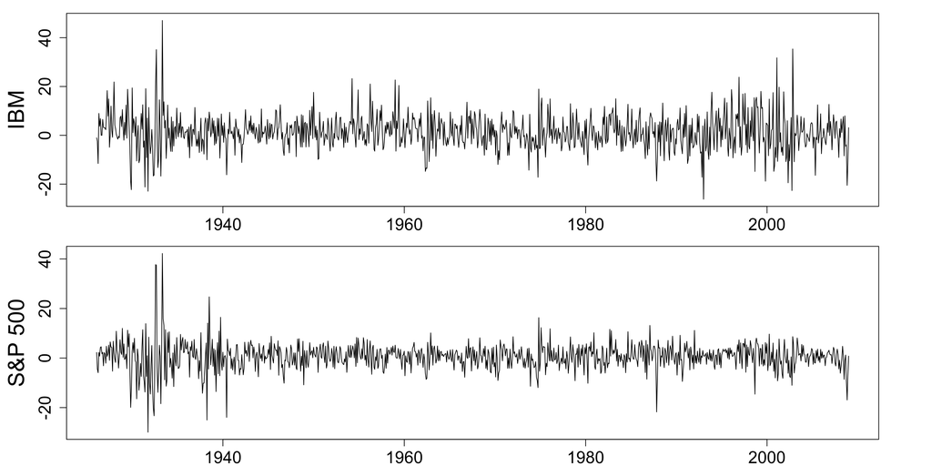

```r
ibmsp2608 <- read.table("data/m-ibmsp2608.txt", header = T)
ibmsp2608$date <- ibmsp2608$date %>% as.character() %>%  as.Date(format="%Y%m%d")
ibmsp2608[,2:3] <- ibmsp2608[,2:3] * 100
par(mfrow=c(2,1), mar=c(2,5,1,4))
plot(ibmsp2608$date, ibmsp2608[,2], type="l", ylab="IBM", xlab="Date", cex.lab=2, cex.axis=1.5)
plot(ibmsp2608$date, ibmsp2608[,3], type="l", ylab="S&P 500", xlab="Date", cex.lab=2, cex.axis=1.5)
```

We are going yo fit a VAR(5) model to the bivariate series:

```r
VAR_QR <- stan_model("models/Chapter_8/VAR_QR.stan")
r <-  ibmsp2608[,2:3]
fit_VAR_QR <- sampling(VAR_QR, data = list(N=nrow(r), K=ncol(r), y=r, p=5, ncol=2), chains = 4, cores = 4, iter=500)
```

```r
print(fit_VAR_QR, pars=c("mu", "Sigma", "phi"))
```

```
## Inference for Stan model: VAR_QR.
## 4 chains, each with iter=500; warmup=250; thin=1;
## post-warmup draws per chain=250, total post-warmup draws=1000.
##
##             mean se_mean   sd  2.5%   25%   50%   75% 97.5% n_eff Rhat
## mu[1]       1.23    0.01 0.23  0.76  1.08  1.23  1.38  1.72  1297    1
## mu[2]       0.51    0.01 0.18  0.17  0.38  0.52  0.62  0.86  1293    1
## Sigma[1,1] 50.01    0.06 2.21 45.74 48.44 49.98 51.57 54.26  1457    1
## Sigma[1,2] 24.69    0.04 1.45 21.92 23.64 24.68 25.72 27.52  1230    1
## Sigma[2,1] 24.69    0.04 1.45 21.92 23.64 24.68 25.72 27.52  1230    1
## Sigma[2,2] 30.02    0.04 1.34 27.60 29.12 29.95 30.84 32.86  1229    1
## phi[1,1,1] -0.03    0.00 0.04 -0.11 -0.06 -0.03 -0.01  0.05  1081    1
## phi[1,1,2] -0.03    0.00 0.03 -0.09 -0.05 -0.03 -0.01  0.02  1024    1
## phi[1,2,1]  0.16    0.00 0.05  0.05  0.12  0.16  0.19  0.26   978    1
## phi[1,2,2]  0.12    0.00 0.04  0.04  0.09  0.12  0.15  0.20   994    1
## phi[2,1,1]  0.09    0.00 0.04  0.00  0.06  0.09  0.12  0.17  1161    1
## phi[2,1,2]  0.04    0.00 0.03 -0.02  0.02  0.04  0.07  0.10  1206    1
## phi[2,2,1] -0.17    0.00 0.05 -0.27 -0.20 -0.17 -0.13 -0.06  1110    1
## phi[2,2,2] -0.05    0.00 0.04 -0.13 -0.08 -0.05 -0.02  0.04  1407    1
## phi[3,1,1]  0.05    0.00 0.04 -0.03  0.02  0.05  0.07  0.13  1409    1
## phi[3,1,2]  0.02    0.00 0.03 -0.04  0.00  0.02  0.04  0.08  1228    1
## phi[3,2,1] -0.11    0.00 0.05 -0.22 -0.15 -0.11 -0.08 -0.01  1196    1
## phi[3,2,2] -0.13    0.00 0.04 -0.20 -0.15 -0.13 -0.10 -0.05  1395    1
## phi[4,1,1] -0.02    0.00 0.04 -0.11 -0.05 -0.02  0.00  0.06  1394    1
## phi[4,1,2]  0.02    0.00 0.03 -0.05  0.00  0.02  0.04  0.09  1241    1
## phi[4,2,1] -0.01    0.00 0.05 -0.11 -0.04 -0.01  0.03  0.10  1163    1
## phi[4,2,2]  0.02    0.00 0.04 -0.06 -0.01  0.02  0.05  0.10  1277    1
## phi[5,1,1] -0.05    0.00 0.04 -0.13 -0.08 -0.05 -0.03  0.03  1269    1
## phi[5,1,2] -0.07    0.00 0.03 -0.13 -0.09 -0.07 -0.05 -0.01  1227    1
## phi[5,2,1]  0.14    0.00 0.05  0.03  0.10  0.13  0.17  0.24  1371    1
## phi[5,2,2]  0.12    0.00 0.04  0.04  0.09  0.12  0.15  0.20  1313    1
##
## Samples were drawn using NUTS(diag_e) at Sat Jun 19 16:45:31 2021.
## For each parameter, n_eff is a crude measure of effective sample size,
## and Rhat is the potential scale reduction factor on split chains (at
## convergence, Rhat=1).
```

The estimated parameters are very similar to Tsay’s full model of TABLE 8.4.  
There is a unidirectional dynamic relationship from the monthly S&P 500 index return to the IBM return. IBM returns are affected by the past movements of the S&P 500 index However, past movements of IBM stock returns do not significantly affect the S&P 500 index, even though the two returns have substantial concurrent correlation.  
We can plot the posterior concurrent correlation:

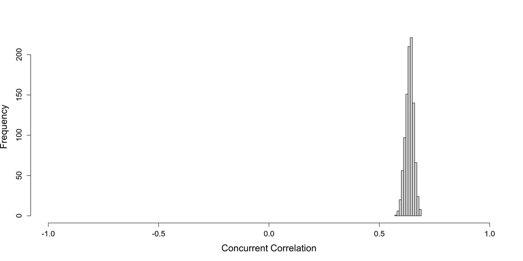

```r
Sigma <- extract(fit_VAR_QR, pars=c("Sigma"))[[1]]
corr <- (Sigma[,1,2] / sqrt(Sigma[,1,1] * Sigma[,2,2]))
hist(corr, xlim=c(-1,1), xlab="Concurrent Correlation", cex.lab=1.5, cex.axis=1.25, main="")
```

We can check the adequacy of the model by testing the autocorrelation using the multivariate Ljung-Box test:

```r
library(portes)
r <- ibmsp2608[,2:3]
mu_hat <- extract(fit_VAR_QR, pars=c("mu"))[[1]] %>% colMeans()
phi_hat <- extract(fit_VAR_QR, pars=c("phi"))[[1]] %>% apply(., 2, function(x)colMeans(x))
a_hat <- matrix(nrow = nrow(fit_VAR_QR), ncol = 2)
for(t in 6:nrow(fit_VAR_QR)) {
  mu_tmp <- mu_hat
  for(i in 1:5)
    mu_tmp <- mu_tmp + (matrix(phi_hat[,i], ncol=2) %>% t) %*% unlist(r[t-i,])
  a_hat[t,] <- unlist(r[t,]) - mu_tmp
}
LjungBox(a_hat %>% na.omit, lags = 1:8)
```

```
##  lags statistic df   p-value
##     1  2.779259  4 0.5954183
##     2  3.732322  8 0.8804308
##     3  9.761490 12 0.6368760
##     4 12.160781 16 0.7328397
##     5 17.899709 20 0.5940149
##     6 20.262478 24 0.6817558
##     7 23.106503 28 0.7276919
##     8 32.682912 32 0.4332629
```

## 8.3 VECTOR MOVING-AVERAGE MODELS

Vector moving-average models are the multivariate version of MA processes, a VMA(1) is defined as follows:

$$r_t = \theta_0 + \Theta a_{t-1} + a_{t}$$

where $\theta_0$ is a k-dimensional vector, $\Theta$ is a k × k matrix, and {$a_t$} is a sequence of serially uncorrelated random vectors with mean zero and covariance matrix $\Sigma$. It is required that the covariance matrix $\Sigma$ exists. The VMA(p) model can be naively coded in Stan as follows:

```stan
data {
  int<lower=0> N;
  int<lower=0> K;
  matrix[N,K] y;
  int Q;
}

transformed data {
  vector[K] y_vector[N];
  for(i in 1:N)
    y_vector[i] = to_vector(y[i,]);
}

parameters {
  vector[K] mu;
  cov_matrix[K] Sigma;
  matrix[K,K] Theta[Q];
}

transformed parameters {
  matrix[K,N] epsilon;       // error terms
  for (t in 1:N) {
    epsilon[,t] = y_vector[t] - mu;
    for(q in 1:min(t-1, Q))
      epsilon[,t] = epsilon[,t] -  Theta[q] * epsilon[,t-q];
  }
}
model {
  vector[K] eta[N];
  mu ~ normal(0,5);
  Sigma ~ inv_wishart(3, diag_matrix(rep_vector(2, K)));
  for(k in 1:Q)
    for(i in 1:K)
      for(j in 1:K)
        Theta[k][i,j] ~ normal(0, 1);
  for(t in 1:N) {
    eta[t] = mu;
    for(q in 1:min(t-1, Q))
      eta[t] += Theta[q] * epsilon[,t - q];
  }
  y_vector ~ multi_normal(eta, Sigma);
}

generated quantities {
  vector[N] log_lik;
  {
    for(i in 1:Q)
      log_lik[i] = multi_normal_lpdf(y[i,] | mu , Sigma);
    for (t in (Q+1):N) {
      vector[K] mu_tmp = mu;
      for(i in 1:Q)
        mu_tmp += Theta[i] * to_vector(y[t-i,]);
      log_lik[t] = multi_normal_lpdf(y[t,] | mu_tmp, Sigma);
    }
  }
}
```

We will fit to the same data as the VAR model before:

```r
VMA <- stan_model("models/Chapter_8/VMA.stan")
r <-  ibmsp2608[,2:3]
fit_VMA <- sampling(VMA, data = list(N=nrow(r), K=ncol(r), y=r, p=5), chains = 4, cores = 4, iter=500, init=0)
```

```r
print(fit_VMA, pars=c("mu", "Sigma", "Theta"))
```

```
## Inference for Stan model: VMA.
## 4 chains, each with iter=500; warmup=250; thin=1;
## post-warmup draws per chain=250, total post-warmup draws=1000.
##
##               mean se_mean   sd  2.5%   25%   50%   75% 97.5% n_eff Rhat
## mu[1]         1.34    0.01 0.23  0.87  1.20  1.34  1.48  1.80  1361    1
## mu[2]         0.58    0.00 0.18  0.21  0.47  0.58  0.71  0.95  1493    1
## Sigma[1,1]   49.87    0.05 2.21 45.73 48.39 49.79 51.25 54.57  1689    1
## Sigma[1,2]   24.62    0.04 1.44 22.09 23.56 24.56 25.61 27.38  1461    1
## Sigma[2,1]   24.62    0.04 1.44 22.09 23.56 24.56 25.61 27.38  1461    1
## Sigma[2,2]   29.91    0.03 1.30 27.57 29.02 29.87 30.75 32.60  1441    1
## Theta[1,1,1] -0.03    0.00 0.04 -0.11 -0.06 -0.03  0.00  0.05   906    1
## Theta[1,1,2]  0.16    0.00 0.05  0.06  0.12  0.16  0.19  0.26   922    1
## Theta[1,2,1] -0.03    0.00 0.03 -0.09 -0.05 -0.03 -0.01  0.03   801    1
## Theta[1,2,2]  0.12    0.00 0.04  0.04  0.09  0.12  0.15  0.20   883    1
## Theta[2,1,1]  0.08    0.00 0.04  0.00  0.05  0.08  0.10  0.16   855    1
## Theta[2,1,2] -0.15    0.00 0.05 -0.25 -0.18 -0.14 -0.11 -0.04   888    1
## Theta[2,2,1]  0.03    0.00 0.03 -0.03  0.01  0.03  0.05  0.10   819    1
## Theta[2,2,2] -0.03    0.00 0.04 -0.11 -0.06 -0.03  0.00  0.05   739    1
## Theta[3,1,1]  0.05    0.00 0.04 -0.04  0.02  0.05  0.08  0.13   885    1
## Theta[3,1,2] -0.12    0.00 0.06 -0.23 -0.16 -0.12 -0.08 -0.02   929    1
## Theta[3,2,1]  0.02    0.00 0.03 -0.05 -0.01  0.01  0.04  0.08   940    1
## Theta[3,2,2] -0.13    0.00 0.04 -0.21 -0.15 -0.13 -0.10 -0.05  1002    1
## Theta[4,1,1] -0.02    0.00 0.04 -0.10 -0.05 -0.02  0.01  0.06   794    1
## Theta[4,1,2] -0.04    0.00 0.05 -0.15 -0.08 -0.05 -0.01  0.06   713    1
## Theta[4,2,1]  0.03    0.00 0.03 -0.04  0.00  0.03  0.05  0.09   641    1
## Theta[4,2,2] -0.02    0.00 0.04 -0.11 -0.05 -0.02  0.01  0.06   662    1
## Theta[5,1,1] -0.04    0.00 0.04 -0.11 -0.07 -0.04 -0.01  0.04   686    1
## Theta[5,1,2]  0.13    0.00 0.05  0.03  0.10  0.13  0.17  0.24   760    1
## Theta[5,2,1] -0.05    0.00 0.03 -0.11 -0.07 -0.05 -0.03  0.01   692    1
## Theta[5,2,2]  0.13    0.00 0.04  0.05  0.10  0.13  0.16  0.21   743    1
##
## Samples were drawn using NUTS(diag_e) at Sat Jun 26 14:21:12 2021.
## For each parameter, n_eff is a crude measure of effective sample size,
## and Rhat is the potential scale reduction factor on split chains (at
## convergence, Rhat=1).
```

The estimates are similar to Tsay’s in TABLE 8.6, except that all Theta’s signs are inverted! I am not quite sure about the reason.

## 8.4 VECTOR ARMA MODELS

Vector arma models are the multivariate version of ARMA processes, a VARMA(1,1) is defined as follows:

$$r_t = \phi_0 + \Phi r_{t-1} + \Theta a_{t-1} + a_{t}$$

where $\phi_0$ is a k-dimensional vector, $\Phi$ and $\Theta$ are k × k matrices, and {$a_t$} is a sequence of serially uncorrelated random vectors with mean zero and covariance matrix $\Sigma$. It is required that the covariance matrix $\Sigma$ exists. The VARMA(1,1) model can be naively coded in Stan as follows:

```stan
data {
  int<lower=1> N;            // num observations
  int K;                    // Matrices size
  matrix[N,K] y;                // observed outputs

}
parameters {
  vector[K] mu;                   // mean coeff
  matrix[K,K] phi;                  // autoregression coeff
  matrix[K,K] theta;                // moving avg coeff
  cov_matrix[K] Sigma;
}
model {
  vector[K] err[N];
  mu ~ normal(0, 10);
  for(i in 1:K)
    for(j in 1:K) {
        phi[i,j] ~ normal(0, 1);
        theta[i,j] ~ normal(0, 1);
    }
  Sigma ~ inv_wishart(3, diag_matrix(rep_vector(2, K)));
  err[1] = to_vector(y[1,]) - mu + phi * mu;
  err[1] ~ multi_normal(rep_vector(0, 2), Sigma);
  for (t in 2:N)
    err[t] = to_vector(y[t]) - (mu + phi * to_vector(y[t-1]) + theta * err[t-1]);
  err ~ multi_normal(rep_vector(0, 2), Sigma);

}

generated quantities {
  vector[N] log_lik;
  vector[K] err[N];
  {
      err[1] = to_vector(y[1,]) - mu + phi * mu;
      log_lik[1] = multi_normal_lpdf(err[1] | rep_vector(0, 2), Sigma);
      for (t in 2:N) {
        err[t] = to_vector(y[t]) - (mu + phi * to_vector(y[t-1]) + theta * err[t-1]);
        log_lik[t] = multi_normal_lpdf(err[t] | rep_vector(0, 2), Sigma);
      }
  }

}
```

However, we can instead use a reparametrized form where we decompose the covariance matrix $\Sigma$ into a diagonal matrix of the conditional standard deviations and a conditional correlation matrix:

```stan
data {
  int<lower=1> N;            // num observations
  int K;                  // Matrices size
  matrix[N,K] y;                // observed outputs

}

transformed data {
  matrix[K,N] y_vector;
  y_vector = y';
}

parameters {
  vector[K] mu;                   // mean coeff
  matrix[K,K] phi;                  // autoregression coeff
  matrix[K,K] theta;                // moving avg coeff
  corr_matrix[K] Omega;
  vector<lower=0>[K] tau;
}

transformed parameters {
  vector[K] epsilon[N];
  matrix[K,K] Sigma;
  Sigma = quad_form_diag(Omega, tau);
  epsilon[1] = y_vector[,1] - mu + phi * mu;
  for (t in 2:N)
    epsilon[t] = y_vector[,t] - (mu + phi * y_vector[,t-1] + theta * epsilon[t-1]);
}
model {
  mu ~ normal(0, 10);
  for(i in 1:K)
    for(j in 1:K) {
        phi[i,j] ~ normal(0, 1);
        theta[i,j] ~ normal(0, 1);
    }
  tau ~ exponential(1);
  Omega ~ lkj_corr(2);
  epsilon ~ multi_normal(rep_vector(0, 2), Sigma);
}

generated quantities {
  vector[N] log_lik;
  vector[K] err[N];
  {
      err[1] = y_vector[,1] - mu + phi * mu;
      log_lik[1] = multi_normal_lpdf(err[1] | rep_vector(0, 2), Sigma);
      for (t in 2:N) {
        err[t] = y_vector[,t] - (mu + phi * y_vector[,t-1] + theta * err[t-1]);
        log_lik[t] = multi_normal_lpdf(err[t] | rep_vector(0, 2), Sigma);
      }
  }

}
```

We are going to apply the VARMA model to two U.S. monthly interest rate series from April 1953 to January 2001. The first series is the 1-year Treasury constant maturity rate, and the second series is the 3-year Treasury constant maturity rate. There are 574 observations. To ensure the positiveness of U.S. interest rates, we analyze the log series:

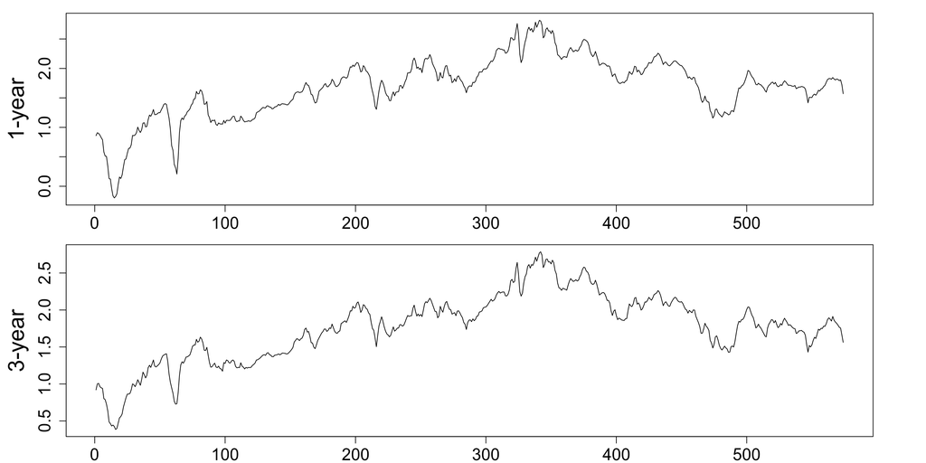

```r
r <- read.table("data/m-gs1n3-5301.txt", header = F)
colnames(r) <- c("1-year", "3-year", "date")
par(mfrow=c(2,1), mar=c(2,5,1,4))
plot(log(r[,1]), type="l", ylab="1-year", xlab="Date", cex.lab=2, cex.axis=1.5)
plot(log(r[,2]), type="l", ylab="3-year", xlab="Date", cex.lab=2, cex.axis=1.5)
```

We will fit the VARMA(1,1) model:

```r
VARMA_r <- stan_model("models/Chapter_8/VARMA_reparametrized.stan")
fit_VARMA <- sampling(VARMA_r, data = list(N=nrow(r), K=2, y=log(r[,c(1,2)])), chains = 4, cores = 4, iter=500, init=0)
```

```r
print(fit_VARMA, pars=c("mu", "phi", "theta", "Sigma", "Omega", "tau"))
```

```
## Inference for Stan model: VARMA_reparametrized.
## 4 chains, each with iter=500; warmup=250; thin=1;
## post-warmup draws per chain=250, total post-warmup draws=1000.
##
##             mean se_mean   sd  2.5%   25%   50%  75% 97.5% n_eff Rhat
## mu[1]      -0.01    0.00 0.02 -0.06 -0.03 -0.01 0.00  0.03   242 1.01
## mu[2]       0.01    0.00 0.02 -0.03  0.00  0.01 0.02  0.04   215 1.02
## phi[1,1]    0.90    0.00 0.05  0.81  0.87  0.89 0.93  1.00   187 1.03
## phi[1,2]    0.11    0.00 0.05 -0.01  0.07  0.11 0.14  0.21   180 1.03
## phi[2,1]   -0.03    0.00 0.04 -0.10 -0.06 -0.03 0.00  0.05   181 1.03
## phi[2,2]    1.02    0.00 0.05  0.93  0.99  1.02 1.05  1.11   170 1.03
## theta[1,1]  0.39    0.01 0.10  0.18  0.32  0.39 0.45  0.58   313 1.01
## theta[1,2] -0.04    0.01 0.12 -0.26 -0.12 -0.04 0.03  0.20   317 1.00
## theta[2,1]  0.18    0.00 0.09  0.00  0.12  0.17 0.23  0.34   332 1.01
## theta[2,2]  0.10    0.01 0.10 -0.09  0.03  0.10 0.17  0.31   335 1.01
## Sigma[1,1]  0.01    0.00 0.00  0.00  0.00  0.01 0.01  0.01   451 1.00
## Sigma[1,2]  0.00    0.00 0.00  0.00  0.00  0.00 0.00  0.00   423 1.00
## Sigma[2,1]  0.00    0.00 0.00  0.00  0.00  0.00 0.00  0.00   423 1.00
## Sigma[2,2]  0.00    0.00 0.00  0.00  0.00  0.00 0.00  0.00   472 1.00
## Omega[1,1]  1.00     NaN 0.00  1.00  1.00  1.00 1.00  1.00   NaN  NaN
## Omega[1,2]  0.92    0.00 0.01  0.90  0.91  0.92 0.92  0.93   514 1.00
## Omega[2,1]  0.92    0.00 0.01  0.90  0.91  0.92 0.92  0.93   514 1.00
## Omega[2,2]  1.00    0.00 0.00  1.00  1.00  1.00 1.00  1.00   125 1.00
## tau[1]      0.07    0.00 0.00  0.07  0.07  0.07 0.07  0.08   452 1.00
## tau[2]      0.06    0.00 0.00  0.06  0.06  0.06 0.06  0.07   472 1.00
##
## Samples were drawn using NUTS(diag_e) at Sat Jun 26 15:57:25 2021.
## For each parameter, n_eff is a crude measure of effective sample size,
## and Rhat is the potential scale reduction factor on split chains (at
## convergence, Rhat=1).
```

We can check the adequacy of the fitting by looking at the residuals:

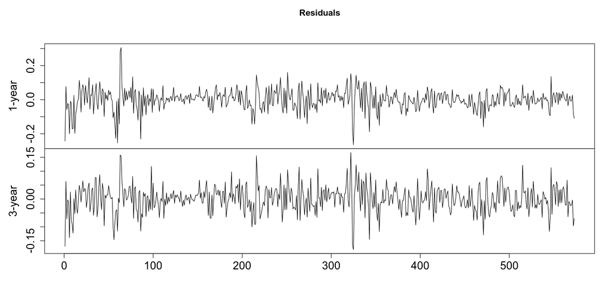

```r
err <- extract(fit_VARMA, pars=c("err"))[[1]] %>% colMeans()
colnames(err) <- c("1-year", "3-year")
plot.ts(err[-1,], main="Residuals", cex.axis=1.5, cex.lab=1.5, xlab="")
```

The interest rate series are highly contemporaneously correlated. The concurrent correlation coefficient is:

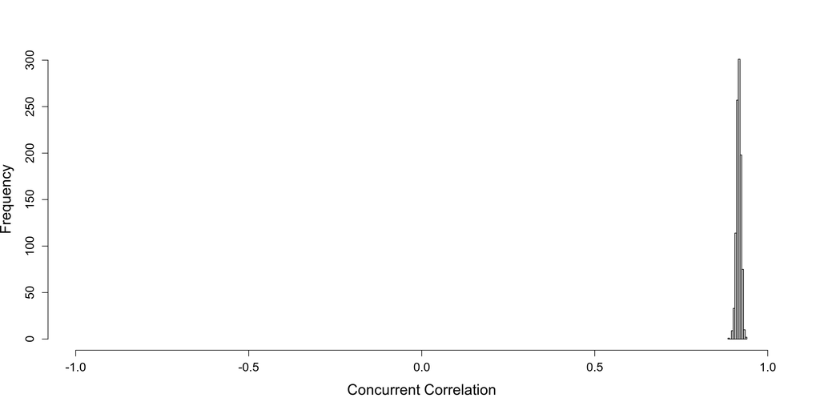

```r
Omega <- extract(fit_VARMA, pars=c("Omega"))[[1]]
hist(Omega[,1,2], xlim=c(-1,1), xlab="Concurrent Correlation", cex.lab=1.5, cex.axis=1.25, main="")
```